# h2dis_jcr

```python
%matplotlib inline

import math
import os
import matplotlib as mpl
import matplotlib.pyplot as plt
import numpy as np
import amjuel
import ehr
import xsection as xs
```

We first use the H collisional radiative code, *collrad*, to model the fate of the products of dissociative excitation of H$_{2}$:

$\frac{N_{n}}{n_{H_{2}}} = - (Q^{-1})_{nm} E_{H_{2},m} \equiv R_{H}^{H_{2}}(p)$.

For a detailed explanation of the H CR model, see the DEGAS 2 User's Manual. In the initial implementation of the above expression, these products were specified via reactions in Janev, Langer, Evans and Post (JLEP):

$E_{H_{2},m} = [< \sigma v>_{(2.2.6)} + 2< \sigma v>_{(2.2.7)}, < \sigma v>_{(2.2.8)}, 0, ... 0 ... ]$.

The key step towards most closely reproducing the effective H$_{2}$ rates from AMJUEL is to replace these with the corresponding set computed via Sawada's subroutine, providing values for all $n$.

Using the notation from Kotov's thesis, the **effective dissociation rate for H$_{2}$** is:

$D_{H_{2}} = C_{H_{2}}(X^{1}\Sigma_{g}^{+}, b^{3}\Sigma_{u}^{+}) + \sum_{p^{\prime} > 1} [ A_{H}(p^{\prime},1)/n_{e} + F_{H}(p^{\prime},1)] R_{H}^{H_{2}}(p^{\prime}) + \sum_{p^{\prime} > 1} [ A_{H_{2}}(p^{\prime},b^{3}\Sigma_{u}^{+})/n_{e} + F_{H_{2}}(p^{\prime},b^{3}\Sigma_{u}^{+})] R_{2H}^{H_{2}}(p^{\prime})$,

where $C_{H_{2}}(X^{1}\Sigma_{g}^{+}, b^{3}\Sigma_{u}^{+})$ is analogous to $< \sigma v >_{(2.2.5)}$, the familiar dissociation rate, $A_{H}(p^{\prime},1)$ is the radiative decay rate for H$(p^{\prime})$ to the ground state, and $F_{H}(p^{\prime},1)$ is the corresponding de-excitation rate. Note that in the H collisional radiative model, the combination $A_{H}(p^{\prime},1)/n_{e} + F_{H}(p^{\prime},1)$ appears enough times to merit its own symbol, $\gamma(p^{\prime})$, or just *gam* in the collrad code. The second sum above represents an intermediate excitation to a higher H$_{2}$ excited state, followed by radiative decay or de-excitation to the unstable $b^{3}\Sigma_{u}^{+}$ state.

In the *collrad* code, the first term is taken to be $< \sigma v >_{(2.2.5)}$. As is described in JLEP, this rate assumes that the $a^{3}\Sigma_{g}^{+}$ and $c^{3}\Sigma_{u}$ excited states both radiatively decay to the unstable $b^{3}\Sigma_{u}^{+}$ state. The problem is that the $c$ state is metastable and does not directly decay to the $b$ state. Sawada's H$_{2}$ CR model accounts for this, first, by including in the first term only transitions directly to the $b$ state; this is why the AMJUEL rate is smaller than the one from the *collrad* result even in the coronal limit. Second, any other collisional radiative transitions between the molecular states are incorporated via the third term; the *collrad* model effectively misses these contributions.

Because of these shortcomings in the *collrad* model, we will primarily rely on the AMJUEL rates, obtained from Sawada's code, for the effective dissociation rate. The one limitation in the AMJUEL rates is that the polynomial fits used to compute them are unreliable above $10^{3}$ eV. Fortunately, the *collrad* rates not only behave similarly for temperatures in the vicinity of $10^{3}$ eV, their values happen to be numerically similar. Consequently, we can use the *collrad* rates for higher temperatures by rescaling to match the AMJUEL values at $10^{3}$ eV.

First, read in the data from the *collrad* model; this contains all of the molecular processes:

```python
h2cr_19_saw = ehr.ehr_data('fort.19')
print(h2cr_19_saw.data_dict.keys())
```

```
True
dict_keys(['  H2 Dissociation Rate(jt,jn) (cm**3 s**-1)  Te(jt) = 10**(-1.2 + (jt-1)/10) jt=1,60\n', '  H2 Dissociative Ionization Rate(jt,jn) (cm**3 s**-1)\n', '  H2+ Dissociative Recombination Rate(jt,jn)  (cm**3 s**-1)\n', '  H2+ Dissociation Rate(jt,jn)  (cm**3 s**-1)\n', '  H2+ Dissociative Ion…
```

```python
D_H2_saw = h2cr_19_saw.get_one_var('H2 Dissociation Rate')
```

We will be comparing with the reaction rate previously used by DEGAS 2 for this process. Note that it has neither the second or third terms in the above expression for the effective reaction rate. In particular, the absence of the second one, representing decayed dissociative excitation products, is responsible for the old rate being so much lower at the higher $T_{e}$.

```python
data_dir = '../'
h2dis_nc = xs.xs_netCDF.read_ncfile('h2dis',data_dir)
h2dis_nc.xs.list_vars()
print('  ')
h2dis_nc.xs.print_var(0)
old_rate = h2dis_nc.xs.get_var4plot(0)
print('  ')
h2dis_nc.xs.print_var(2)
old_eloss = h2dis_nc.xs.get_var4plot(2)
```

```
 j              Name                   Units
 0 reaction_rate                  cm^3/s
 1 dissociation_energy            eV
 2 background_energy_loss_rate    eV*cm^3/s

Dependent variable:  reaction_rate  Units:  cm^3/s
 Multiplier:  1.00000e-06  Spacing:  log

  Indep. var.     Units    Multiplier  Spacing     Min.        Max.
temperature     eV         1.60218e-19 log      1.00000e+00 5.01187e+04

Dependent variable:  background_energy_loss_rate  Units:  eV*cm^3/s
 Multiplier:  1.60218e-25  Spacing:  log

  Indep. var.     Units    Multiplier  Spacing     Min.        Max.
temperature     eV         1.60218e-19 log      1.00000e+00 5.01187e+04
```

Now read in the data from AMJUEL:

```python
amj_file = 'amjuel.tex'
```

Use the same grid for the two sets of data.

```python
ehr19Te = h2cr_19_saw.get_Te()
ehr19ne = h2cr_19_saw.get_ne()
num_Te = ehr19Te.shape[0]
num_ne = ehr19ne.shape[0]
```

```python
H123 = 'H.4'
reacstr = '2.2.5'
fit_coef = amjuel.get_AMJUEL_fit(amj_file,H123,reacstr)
data_225 = np.zeros((num_ne,num_Te))
for jt in range(num_Te):
    for jn in range(num_ne):
        data_225[jn,jt] = amjuel.ne_Te_exp_fit(fit_coef,ehr19ne[jn],ehr19Te[jt])
```

This is where we do the rescaling:

```python
Te_match = np.argwhere(ehr19Te >= 1.e3)[0]
print(Te_match)
```

```
[42]
```

```python
D_H2_rev = np.zeros_like(D_H2_saw)
for jn in range(num_ne):
    scale_factor = data_225[jn,Te_match] / D_H2_saw[jn,Te_match]
    for jt in range(num_Te):
        if (jt < Te_match):
            D_H2_rev[jn,jt] = data_225[jn,jt]
        else:
            D_H2_rev[jn,jt] = scale_factor * D_H2_saw[jn,jt]
```

Make a comparison plot.

The designation "JCR" here and in the name of this and the other associated molecular dissociation reaction files stands for "Janev Collisional Radiative" since the original approach was to use the Janev rates for the dissociative excitation product distribution in *collrad*.

The lines labeled "JCR Saw" refer to the output obtained from the *collrad* code with the Sawada subroutine for the dissociative excitation product distribution. Then, "JCR Rev" refers to the set of revised rates obtained by extrapolating the AMJUEL rates via the above rescaling process.

The previous DEGAS 2 rate for this process, without collisional radiative effects, is included for comparison. Again, this is lower at higher $T_{e}$ since it lacks contributions from the decay or de-excitation of dissociative excitation products.

The different colors represent different densities, as is indicated by the legend.

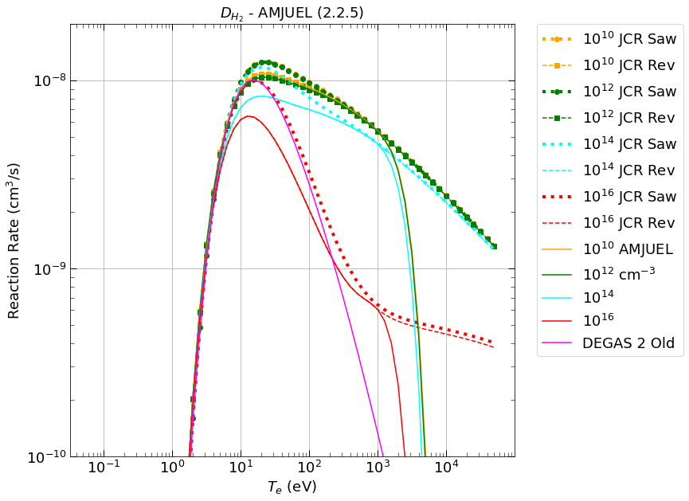

```python
plt.figure(figsize=(10,10))
plt.plot(ehr19Te,D_H2_saw[0,:],'-o',label='$10^{10}$ JCR Saw',lw=4,ls=':',color='orange')
plt.plot(ehr19Te,D_H2_rev[0,:],'s',label='$10^{10}$ JCR Rev',ls='--',color='orange')
plt.plot(ehr19Te,D_H2_saw[4,:],'-o',label='$10^{12}$ JCR Saw',lw=4,ls=':',color='green')
plt.plot(ehr19Te,D_H2_rev[4,:],'s',label='$10^{12}$ JCR Rev',ls='--',color='green')
plt.plot(ehr19Te,D_H2_saw[8,:],label='$10^{14}$ JCR Saw',lw=4,ls=':',color='cyan')
plt.plot(ehr19Te,D_H2_rev[8,:],label='$10^{14}$ JCR Rev',ls='--',color='cyan')
plt.plot(ehr19Te,D_H2_saw[12,:],label='$10^{16}$ JCR Saw',lw=4,ls=':',color='red')
plt.plot(ehr19Te,D_H2_rev[12,:],label='$10^{16}$ JCR Rev',ls='--',color='red')
plt.plot(ehr19Te,data_225[0,:],label='$10^{10}$ AMJUEL',color='orange')
plt.plot(ehr19Te,data_225[4,:],label='$10^{12}$ cm$^{-3}$',color='green')
plt.plot(ehr19Te,data_225[8,:],label='$10^{14}$',color='cyan')
plt.plot(ehr19Te,data_225[12,:],label='$10^{16}$',color='red')
plt.plot(old_rate[0],old_rate[1],label='DEGAS 2 Old',color='magenta')
plt.xlabel('$T_{e}$ (eV)',fontsize=18)
plt.ylabel('Reaction Rate (cm$^{3}$/s)',fontsize=18)
plt.tick_params(which='major',labelsize=18,length=8,width=1,
                direction='in',top='on',right='on')
plt.tick_params(which='minor',length=5,
                direction='in',top='on',right='on')
plt.minorticks_on()
plt.gca().set_yscale('log')
plt.gca().set_xscale('log')
plt.gca().set_ylim((1.e-10,2.e-8))
plt.gca().grid(axis='both',which='major')
plt.title('$D_{H_{2}}$ - AMJUEL (2.2.5)',fontsize=18)
plt.legend(bbox_to_anchor=(1.05,1),loc='upper left',borderaxespad=0,fontsize=18)
```

For the energetics, using the same approach as the original model, which is the same as that used by EIRENE. Namely, the energy of dissociation products, $E_{diss} = 3.0$ eV and electron cooling per dissociation, $E_{loss} = 10.5$ eV. That latter is used to compute an effective background energy loss rate.

```python
E_diss = 3.0
E_loss = 10.5
E_loss_rate = E_loss * D_H2_rev
```

Compare this loss rate with the one previously used by DEGAS 2 for this reaction:

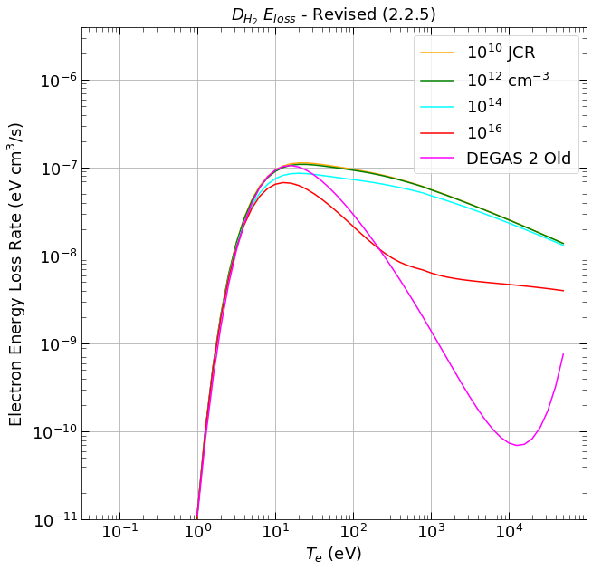

```python
plt.figure(figsize=(10,10))
plt.plot(ehr19Te,E_loss_rate[0,:],
         label='$10^{10}$ JCR',color='orange')
plt.plot(ehr19Te,E_loss_rate[4,:],
         label='$10^{12}$ cm$^{-3}$',color='green')
plt.plot(ehr19Te,E_loss_rate[8,:],
         label='$10^{14}$',color='cyan')
plt.plot(ehr19Te,E_loss_rate[12,:],
         label='$10^{16}$',color='red')
plt.plot(old_eloss[0],old_eloss[1],label='DEGAS 2 Old',color='magenta')
plt.xlabel('$T_{e}$ (eV)',fontsize=18)
plt.ylabel('Electron Energy Loss Rate (eV cm$^{3}$/s)',fontsize=18)
plt.tick_params(which='major',labelsize=18,length=8,width=1,
                direction='in',top='on',right='on')
plt.tick_params(which='minor',length=5,
                direction='in',top='on',right='on')
plt.minorticks_on()
plt.gca().set_yscale('log')
plt.gca().set_xscale('log')
#plt.gca().set_xlim((1.,1.e3))
plt.gca().set_ylim((1.e-11,4.e-6))
plt.gca().grid(axis='both',which='major')
plt.title('$D_{H_{2}}$ $E_{loss}$ - Revised (2.2.5)',fontsize=18)
plt.legend(fontsize=18)
```

As is done for H CR data, e.g., in hionize5.nc, we provide the emission rate for photons, as a power, rather than the excited state population coefficients. As is noted in the introduction above, these coefficients are the result of using the Sawada dissociation excitation coefficients on the right-hand side of the *collrad* atomic collisional radiative model, the same approach used in obtaining the rates for AMJUEL. Consequently, no rescaling is needed.

First, extract the data for all excited states from the file. Note that there are data for $n = 2 \rightarrow 9 \Rightarrow 8$ states.

```python
H2_popn_coef = np.zeros((num_ne,num_Te,8))
for n in range(2,10):
    print(n)
    H2_popn_coef[:,:,n-2] = h2cr_19_saw.get_one_var('H2 Dissociative Excitation n='+str(n))
```

```
2
3
4
5
6
7
8
9
```

```python
H123 = 'H.12'
reacstr = '2.2.5a'
fit_coef = amjuel.get_AMJUEL_fit(amj_file,H123,reacstr)
data_225a = np.zeros((num_ne,num_Te))
for jt in range(num_Te):
    for jn in range(num_ne):
        data_225a[jn,jt] = amjuel.ne_Te_exp_fit(fit_coef,
                                                ehr19ne[jn],ehr19Te[jt])
```

AMJUEL provides the population coefficients, so we use that for the comparison plots:

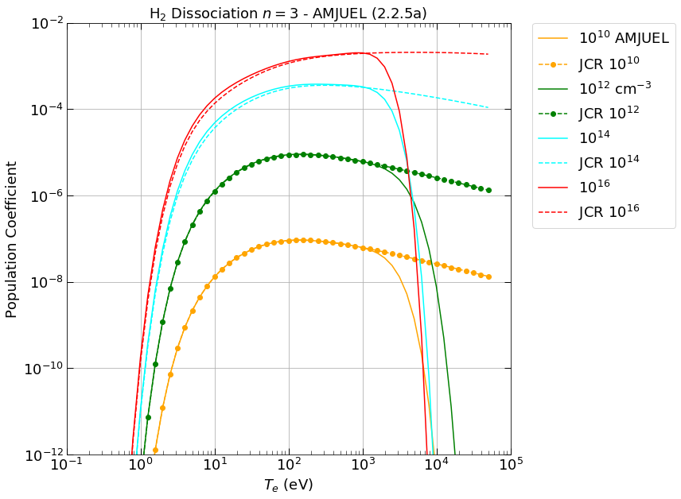

```python
plt.figure(figsize=(10,10))
plt.plot(ehr19Te,data_225a[0,:],label='$10^{10}$ AMJUEL',color='orange')
plt.plot(ehr19Te,
         H2_popn_coef[0,:,1],'-o',
         label='JCR $10^{10}$',color='orange',ls='--')
plt.plot(ehr19Te,data_225a[4,:],label='$10^{12}$ cm$^{-3}$',color='green')
plt.plot(ehr19Te,
         H2_popn_coef[4,:,1],'-o',
         label='JCR $10^{12}$',color='green',ls='--')
plt.plot(ehr19Te,data_225a[8,:],label='$10^{14}$',color='cyan')
plt.plot(ehr19Te,
         H2_popn_coef[8,:,1],
         label='JCR $10^{14}$',color='cyan',ls='--')
plt.plot(ehr19Te,data_225a[12,:],label='$10^{16}$',color='red')
plt.plot(ehr19Te,
         H2_popn_coef[12,:,1],
         label='JCR $10^{16}$',color='red',ls='--')
plt.xlabel('$T_{e}$ (eV)',fontsize=18)
plt.ylabel('Population Coefficient',fontsize=18)
plt.tick_params(which='major',labelsize=18,length=8,width=1,
                direction='in',top='on',right='on')
plt.tick_params(which='minor',length=5,
                direction='in',top='on',right='on')
plt.minorticks_on()
plt.gca().set_yscale('log')
plt.gca().set_xscale('log')
plt.gca().set_xlim((0.1,1.e5))
plt.gca().set_ylim((1.e-12,1.e-2))
plt.gca().grid(axis='both',which='major')
plt.gca().grid(axis='y',which='minor')
plt.title('H$_{2}$ Dissociation $n=3$ - AMJUEL (2.2.5a)',fontsize=18)
plt.legend(bbox_to_anchor=(1.05,1),loc='upper left',borderaxespad=0,fontsize=18)
```

```python
H123 = 'H.12'
reacstr = '2.2.5b'
fit_coef = amjuel.get_AMJUEL_fit(amj_file,H123,reacstr)
data_225b = np.zeros((num_ne,num_Te))
for jt in range(num_Te):
    for jn in range(num_ne):
        data_225b[jn,jt] = amjuel.ne_Te_exp_fit(fit_coef,
                                                ehr19ne[jn],ehr19Te[jt])
```

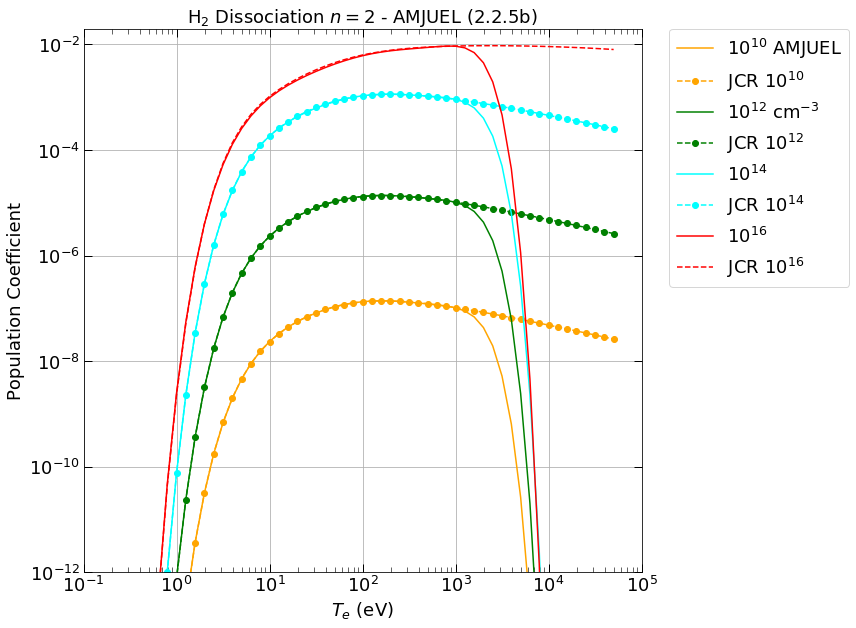

```python
plt.figure(figsize=(10,10))
plt.plot(ehr19Te,data_225b[0,:],label='$10^{10}$ AMJUEL',color='orange')
plt.plot(ehr19Te,
         H2_popn_coef[0,:,0],'-o',
         label='JCR $10^{10}$',color='orange',ls='--')
plt.plot(ehr19Te,data_225b[4,:],label='$10^{12}$ cm$^{-3}$',color='green')
plt.plot(ehr19Te,
         H2_popn_coef[4,:,0],'-o',
         label='JCR $10^{12}$',color='green',ls='--')
plt.plot(ehr19Te,data_225b[8,:],label='$10^{14}$',color='cyan')
plt.plot(ehr19Te,
         H2_popn_coef[8,:,0],'-o',
         label='JCR $10^{14}$',color='cyan',ls='--')
plt.plot(ehr19Te,data_225b[12,:],label='$10^{16}$',color='red')
plt.plot(ehr19Te,
         H2_popn_coef[12,:,0],
         label='JCR $10^{16}$',color='red',ls='--')
plt.xlabel('$T_{e}$ (eV)',fontsize=18)
plt.ylabel('Population Coefficient',fontsize=18)
plt.tick_params(which='major',labelsize=18,length=8,width=1,
                direction='in',top='on',right='on')
plt.tick_params(which='minor',length=5,
                direction='in',top='on',right='on')
plt.minorticks_on()
plt.gca().set_yscale('log')
plt.gca().set_xscale('log')
plt.gca().set_xlim((0.1,1.e5))
plt.gca().set_ylim((1.e-12,2.e-2))
plt.gca().grid(axis='both',which='major')
plt.gca().grid(axis='y',which='minor')
plt.title('H$_{2}$ Dissociation $n=2$ - AMJUEL (2.2.5b)',fontsize=18)
plt.legend(bbox_to_anchor=(1.05,1),loc='upper left',borderaxespad=0,fontsize=18)
```

```python
H123 = 'H.12'
reacstr = '2.2.5c'
fit_coef = amjuel.get_AMJUEL_fit(amj_file,H123,reacstr)
data_225c = np.zeros((num_ne,num_Te))
for jt in range(num_Te):
    for jn in range(num_ne):
        data_225c[jn,jt] = amjuel.ne_Te_exp_fit(fit_coef,ehr19ne[jn],ehr19Te[jt])
```

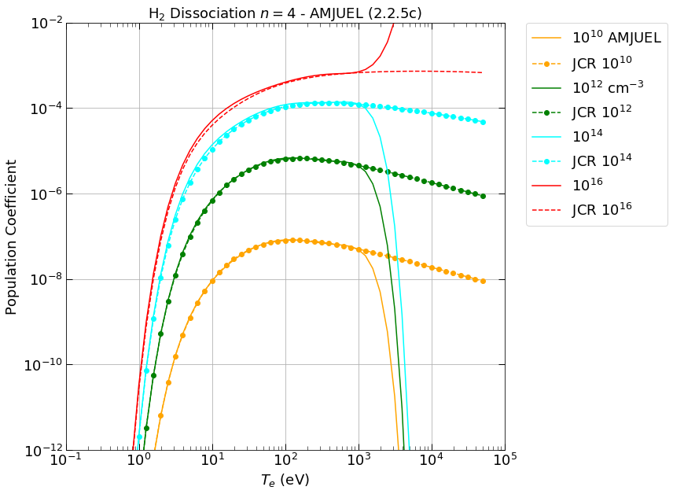

```python
plt.figure(figsize=(10,10))
plt.plot(ehr19Te,data_225c[0,:],label='$10^{10}$ AMJUEL',color='orange')
plt.plot(ehr19Te,
         H2_popn_coef[0,:,2],'-o',
         label='JCR $10^{10}$',color='orange',ls='--')
plt.plot(ehr19Te,data_225c[4,:],label='$10^{12}$ cm$^{-3}$',color='green')
plt.plot(ehr19Te,
         H2_popn_coef[4,:,2],'-o',
         label='JCR $10^{12}$',color='green',ls='--')
plt.plot(ehr19Te,data_225c[8,:],label='$10^{14}$',color='cyan')
plt.plot(ehr19Te,
         H2_popn_coef[8,:,2],'-o',
         label='JCR $10^{14}$',color='cyan',ls='--')
plt.plot(ehr19Te,data_225c[12,:],label='$10^{16}$',color='red')
plt.plot(ehr19Te,
         H2_popn_coef[12,:,2],
         label='JCR $10^{16}$',color='red',ls='--')
plt.xlabel('$T_{e}$ (eV)',fontsize=18)
plt.ylabel('Population Coefficient',fontsize=18)
plt.tick_params(which='major',labelsize=18,length=8,width=1,
                direction='in',top='on',right='on')
plt.tick_params(which='minor',length=5,
                direction='in',top='on',right='on')
plt.minorticks_on()
plt.gca().set_yscale('log')
plt.gca().set_xscale('log')
plt.gca().set_xlim((0.1,1.e5))
plt.gca().set_ylim((1.e-12,1.e-2))
plt.gca().grid(axis='both',which='major')
plt.gca().grid(axis='y',which='minor')
plt.title('H$_{2}$ Dissociation $n=4$ - AMJUEL (2.2.5c)',fontsize=18)
plt.legend(bbox_to_anchor=(1.05,1),loc='upper left',borderaxespad=0,fontsize=18)
```

```python
H123 = 'H.12'
reacstr = '2.2.5d'
fit_coef = amjuel.get_AMJUEL_fit(amj_file,H123,reacstr)
data_225d = np.zeros((num_ne,num_Te))
for jt in range(num_Te):
    for jn in range(num_ne):
        data_225d[jn,jt] = amjuel.ne_Te_exp_fit(fit_coef,ehr19ne[jn],ehr19Te[jt])
```

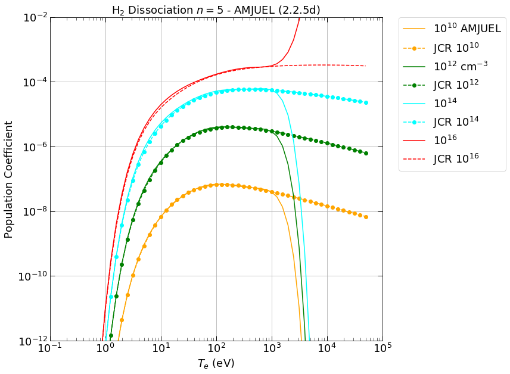

```python
plt.figure(figsize=(10,10))
plt.plot(ehr19Te,data_225d[0,:],label='$10^{10}$ AMJUEL',color='orange')
plt.plot(ehr19Te,
         H2_popn_coef[0,:,3],'-o',
         label='JCR $10^{10}$',color='orange',ls='--')
plt.plot(ehr19Te,data_225d[4,:],label='$10^{12}$ cm$^{-3}$',color='green')
plt.plot(ehr19Te,
         H2_popn_coef[4,:,3],'-o',
         label='JCR $10^{12}$',color='green',ls='--')
plt.plot(ehr19Te,data_225d[8,:],label='$10^{14}$',color='cyan')
plt.plot(ehr19Te,
         H2_popn_coef[8,:,3],'-o',
         label='JCR $10^{14}$',color='cyan',ls='--')
plt.plot(ehr19Te,data_225d[12,:],label='$10^{16}$',color='red')
plt.plot(ehr19Te,
         H2_popn_coef[12,:,3],
         label='JCR $10^{16}$',color='red',ls='--')
plt.xlabel('$T_{e}$ (eV)',fontsize=18)
plt.ylabel('Population Coefficient',fontsize=18)
plt.tick_params(which='major',labelsize=18,length=8,width=1,
                direction='in',top='on',right='on')
plt.tick_params(which='minor',length=5,
                direction='in',top='on',right='on')
plt.minorticks_on()
plt.gca().set_yscale('log')
plt.gca().set_xscale('log')
plt.gca().set_xlim((0.1,1.e5))
plt.gca().set_ylim((1.e-12,1.e-2))
plt.gca().grid(axis='both',which='major')
plt.gca().grid(axis='y',which='minor')
plt.title('H$_{2}$ Dissociation $n=5$ - AMJUEL (2.2.5d)',fontsize=18)
plt.legend(bbox_to_anchor=(1.05,1),loc='upper left',borderaxespad=0,fontsize=18)
```

The only lines we currently maintain in the H CR model are Balmer $\alpha$ ($n = 3 \rightarrow 2$), $\beta$ ($n = 4 \rightarrow 2$), and $\gamma$ ($n= 5 \rightarrow 2$) and Lyman $\alpha$ ($n = 2 \rightarrow 1$). In the interest of simplicity and consistency, have just copied the transition energies and rates from reactionwrite.web, but using eV here instead of ergs.

```python
Eionize = 13.595
E_32 = Eionize * (1./2.**2 - 1./3.**2)
A_32 = 4.41e7
E_21 = Eionize * (1. - 1./2.**2)
A_21 = 4.699e8
E_42 = Eionize * (1./2.**2 - 1./4.**2)
A_42 = 8.419e6
E_52 = Eionize * (1./2.**2 - 1./5.**2)
A_52 = 2.530e6
```

By convention, the quantity in the files is the emission rate per neutral (here, H$_{2}$) and per electron. So, we divide out the electron density.

```python
emission_rate_balmer_alpha = np.zeros((num_ne,num_Te))
emission_rate_balmer_beta = np.zeros((num_ne,num_Te))
emission_rate_balmer_gamma = np.zeros((num_ne,num_Te))
emission_rate_lyman_alpha = np.zeros((num_ne,num_Te))
for jn in range(num_ne):
    emission_rate_balmer_alpha[jn,:] = E_32*A_32*H2_popn_coef[jn,:,3-2]/ehr19ne[jn]
    emission_rate_balmer_beta[jn,:] = E_42*A_42*H2_popn_coef[jn,:,4-2]/ehr19ne[jn]
    emission_rate_balmer_gamma[jn,:] = E_52*A_52*H2_popn_coef[jn,:,5-2]/ehr19ne[jn]
    emission_rate_lyman_alpha[jn,:] = E_21*A_21*H2_popn_coef[jn,:,2-2]/ehr19ne[jn]
```

In the previous DEGAS 2 model for molecular dissociation, only an $n=3$ excited product was included, with the rate coming from JLEP reaction (2.2.8). Read in those data from the netCDF file and make a comparison plot.

```python
h2dis_n3_nc = xs.xs_netCDF.read_ncfile('h2dis_n3',data_dir)
h2dis_n3_nc.xs.list_vars()
print('  ')
h2dis_n3_nc.xs.print_var(3)
old_Dalpha_rate = h2dis_n3_nc.xs.get_var4plot(3)
```

```
 j              Name                   Units
 0 reaction_rate                  cm^3/s
 1 background_energy_loss_rate    eV*cm^3/s
 2 dissociation_energy            eV
 3 emission_rate                  eV*cm^3/s
 4 wavelength_H_alpha             Angstroms
 5 wavelength_D_alpha             Angstroms
 6 wavelength_T_alpha             Angstroms

Dependent variable:  emission_rate  Units:  eV*cm^3/s
 Multiplier:  1.60218e-25  Spacing:  log

  Indep. var.     Units    Multiplier  Spacing     Min.        Max.
temperature     eV         1.60218e-19 log      1.00000e+00 5.01187e+04
```

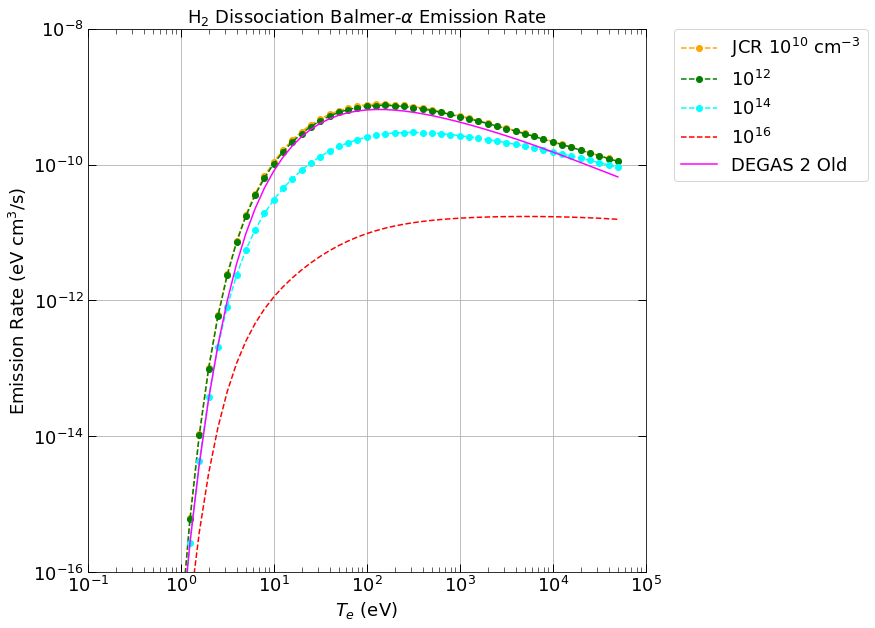

```python
plt.figure(figsize=(10,10))
plt.plot(ehr19Te,
         emission_rate_balmer_alpha[0,:],'-o',
         label='JCR $10^{10}$ cm$^{-3}$',color='orange',ls='--')
plt.plot(ehr19Te,
         emission_rate_balmer_alpha[4,:],'-o',
         label='$10^{12}$',color='green',ls='--')
plt.plot(ehr19Te,
         emission_rate_balmer_alpha[8,:],'-o',
         label='$10^{14}$',color='cyan',ls='--')
plt.plot(ehr19Te,
         emission_rate_balmer_alpha[12,:],
         label='$10^{16}$',color='red',ls='--')
plt.plot(old_Dalpha_rate[0],old_Dalpha_rate[1],label='DEGAS 2 Old',color='magenta')
plt.xlabel('$T_{e}$ (eV)',fontsize=18)
plt.ylabel('Emission Rate (eV cm$^{3}$/s)',fontsize=18)
plt.tick_params(which='major',labelsize=18,length=8,width=1,
                direction='in',top='on',right='on')
plt.tick_params(which='minor',length=5,
                direction='in',top='on',right='on')
plt.minorticks_on()
plt.gca().set_yscale('log')
plt.gca().set_xscale('log')
plt.gca().set_xlim((0.1,1.e5))
plt.gca().set_ylim((1.e-16,1.e-8))
plt.gca().grid(axis='both',which='major')
plt.gca().grid(axis='y',which='minor')
plt.title(r'H$_{2}$ Dissociation Balmer-$\alpha$ Emission Rate',fontsize=18)
plt.legend(bbox_to_anchor=(1.05,1),loc='upper left',borderaxespad=0,fontsize=18)
```

At low densities, the newer rate is very close to the old one since there are few contributions from other excited states. However, these are non-zero, e.g., decays from $n=4$ to $n=3$, causing the new rate to be higher than the old at all $T_{e}$. At higher densities, collisional de-excitation reduces the $n=3$ population.

Writing the data to the netCDF file consists of two steps. The first involves defining the independent and dependent variables and then setting up the data table that holds all of the actual rate data.

The variables being written to this file are:

1. Reaction rate(temperature,density)
2. Dissociation energy (scalar)
3. Background energy loss rate (temperature,density)
4. Emission rate (temperature, density) - default rate is for Balmer-$\alpha$.
5. Emission rate Lyman-$\alpha$ (temperature, density)
6. Emission rate Balmer-$\beta$ (temperature, density)
7. Emission rate Balmer-$\gamma$ (temperature, density)
8. Wavelength H$_{\alpha}$ (emitter mass)
9. Wavelength D$_{\alpha}$ (emitter mass)
10. Wavelength T$_{\alpha}$ (emitter mass)
11. Wavelength Lyman-$\alpha$
12. Wavelength Balmer-$\beta$
13. Wavelength Balmer-$\gamma$

As above, there are num_ne density values and num_Te temperature values. Note that we change from using (density,temperature) in these notebooks to (temperature,density) in the netCDF files. The latter is to be consistent with the convention in the H CR files, such as hionize5.nc. The swap is effected by sending the transpose of the data arrays in the set_data method calls below. We use 4 values of the emitter mass to connect the emitting species with its wavelength.

This initialization call sets the name of the reaction and the netCDF file, and specifies the number of dependent variables.

```python
h2dis_jcr = xs.xs_data('h2dis_jcr',13)
```

Now, loop through the variables, providing the name, evaluation name (not really used), dimensions, units, multiplier, independent variable minimum and maximum, and the spacing method used for interpolation.

```python
h2dis_jcr.set_var(0,['reaction_rate','temperature','density'],'table',
              [num_Te,num_ne],['cm^3/s','eV','cm^-3'],
              [1.e-6,xs.electron_charge,1.e6],
              [ehr19Te[0],ehr19ne[0]],
              [ehr19Te[-1],ehr19ne[-1]],
              ['log']*3)
```

```python
h2dis_jcr.set_var(1,['dissociation_energy'],'table',
              [],['eV'],
              [xs.electron_charge],
              [],
              [],
              ['linear'])
```

```python
for j in range(2,7):
    rate_names = ['background_energy_loss_rate','emission_rate',
           'emission_rate_Lyman_alpha','emission_rate_Balmer_beta',
           'emission_rate_Balmer_gamma']
    h2dis_jcr.set_var(j,[rate_names[j-2],'temperature','density'],'table',
                  [num_Te,num_ne],['eV*cm^3/s','eV','cm^-3'],
                  [1.e-6*xs.electron_charge,xs.electron_charge,1.e6],
                  [ehr19Te[0],ehr19ne[0]],
                  [ehr19Te[-1],ehr19ne[-1]],
                  ['log']*3)
```

```python
for j in range(7,10):
    B_wave_names = ['wavelength_H_alpha','wavelength_D_alpha','wavelength_T_alpha']
    #
    # Copied these from existing files
    #
    wave_mins = [1.5e-27,3.2e-27,4.85e-27]
    wave_maxs = [1.8e-27,3.5e-27,5.15e-27]
    h2dis_jcr.set_var(j,[B_wave_names[j-7],'emitter_mass'],'table',
                  [4],['Angstroms','kilograms'],
                  [1.e-10,1.],
                  [wave_mins[j-7]],
                  [wave_maxs[j-7]],
                  ['linear']*2)
```

```python
for j in range(10,13):
    wave_names = ['wavelength_Lyman_alpha','wavelength_Balmer_beta',
                  'wavelength_Balmer_gamma']
    #
    # Note that the use of table_external here is only
    # for consistency with reactionwrite.web; the particular
    # value has no meaning since we are not using ratecalc here.
    #
    h2dis_jcr.set_var(j,[wave_names[j-10]],'table_external',
                  [],['Angstroms'],
                  [1.e-10],
                  [],
                  [],
                  ['linear'])
```

Fill in the data table.

The wavelength values are entered manually by copying them from reactionwrite.web.

```python
h2dis_jcr.set_data(0,D_H2_rev.T)   # Note the transpose; see above.
h2dis_jcr.set_data(1,E_diss)
h2dis_jcr.set_data(2,E_loss_rate.T)
h2dis_jcr.set_data(3,emission_rate_balmer_alpha.T)
h2dis_jcr.set_data(4,emission_rate_lyman_alpha.T)
h2dis_jcr.set_data(5,emission_rate_balmer_beta.T)
h2dis_jcr.set_data(6,emission_rate_balmer_gamma.T)
h2dis_jcr.set_data(7,np.array([0.,6.56280e3,6.56280e3,0.]))  # H Balmer-alpha
h2dis_jcr.set_data(8,np.array([0.,6.56104e3,6.56104e3,0.]))  # D
h2dis_jcr.set_data(9,np.array([0.,6.56045e3,6.56045e3,0.]))  # T
h2dis_jcr.set_data(10,1.215668e3)  # Lyman-alpha
h2dis_jcr.set_data(11,4.861e3)     # Balmer-beta
h2dis_jcr.set_data(12,4.341e3)     # Balmer-gamma
```

Now open the netCDF file, write in the data using the h2dis xs_data data structures, and close the file.

```python
work_dir = './'
h2dis_jcr_nc = xs.xs_netCDF.write_ncfile(h2dis_jcr,work_dir,
                        'Reference atomic physics data for a reaction in degas 2',
                        'V. 1.0, effective H2 dissociation with CR effects')
h2dis_jcr_nc.close()
```

AMJUEL also provides an effective dissociation rate that incorporates the effects of vibrational excitation via the assumption that the vibrationally excited states are in equilibrium; see the discussion in Kotov's thesis and references therein. The result of this is simply a modified effective dissociation rate. A modified value for the cooling rate is required here since we characterize it as a constant multiplier of the dissociation rate. However, all of the emission rate data and auxiliary information in the file are unaltered; again, this is the approach used by EIRENE. For that reason, we have appended the creation of this second data file to this notebook.

We begin with reading in the data from AMJUEL:

```python
H123 = 'H.4'
reacstr = '2.2.5g'
fit_coef = amjuel.get_AMJUEL_fit(amj_file,H123,reacstr)
data_225g = np.zeros((num_ne,num_Te))
for jt in range(num_Te):
    for jn in range(num_ne):
        data_225g[jn,jt] = amjuel.ne_Te_exp_fit(fit_coef,ehr19ne[jn],ehr19Te[jt])
```

As above, rescale the *collrad* rates above $10^{3}$ eV to avoid the unphysical behavior in the AMJUEL fits at higher temperatures. As the plot below shows, the (2.2.5g) fit is actually reasonable up to $10^{4}$ eV, but the values are so similar to the ones from *collrad* up to that point that the simpler approach of again cutting off at $10^{3}$ eV is preferable.

```python
D_H2g_rev = np.zeros_like(D_H2_saw)
for jn in range(num_ne):
    scale_factor = data_225g[jn,Te_match] / D_H2_saw[jn,Te_match]
    for jt in range(num_Te):
        if (jt < Te_match):
            D_H2g_rev[jn,jt] = data_225g[jn,jt]
        else:
            D_H2g_rev[jn,jt] = scale_factor * D_H2_saw[jn,jt]
```

Again, compare the two. Note that the effect of vibrational excitation is to increase the dissociation rate, narrowing the gap between the AMJUEL and *collrad* rates, again rendering the rescaling approach reasonable.

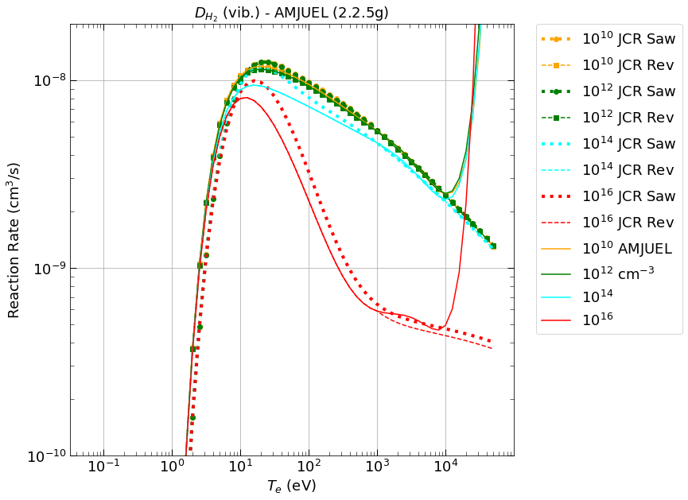

```python
plt.figure(figsize=(10,10))
plt.plot(ehr19Te,D_H2_saw[0,:],'-o',label='$10^{10}$ JCR Saw',lw=4,ls=':',color='orange')
plt.plot(ehr19Te,D_H2g_rev[0,:],'s',label='$10^{10}$ JCR Rev',ls='--',color='orange')
plt.plot(ehr19Te,D_H2_saw[4,:],'-o',label='$10^{12}$ JCR Saw',lw=4,ls=':',color='green')
plt.plot(ehr19Te,D_H2g_rev[4,:],'s',label='$10^{12}$ JCR Rev',ls='--',color='green')
plt.plot(ehr19Te,D_H2_saw[8,:],label='$10^{14}$ JCR Saw',lw=4,ls=':',color='cyan')
plt.plot(ehr19Te,D_H2g_rev[8,:],label='$10^{14}$ JCR Rev',ls='--',color='cyan')
plt.plot(ehr19Te,D_H2_saw[12,:],label='$10^{16}$ JCR Saw',lw=4,ls=':',color='red')
plt.plot(ehr19Te,D_H2g_rev[12,:],label='$10^{16}$ JCR Rev',ls='--',color='red')
plt.plot(ehr19Te,data_225g[0,:],label='$10^{10}$ AMJUEL',color='orange')
plt.plot(ehr19Te,data_225g[4,:],label='$10^{12}$ cm$^{-3}$',color='green')
plt.plot(ehr19Te,data_225g[8,:],label='$10^{14}$',color='cyan')
plt.plot(ehr19Te,data_225g[12,:],label='$10^{16}$',color='red')
plt.xlabel('$T_{e}$ (eV)',fontsize=18)
plt.ylabel('Reaction Rate (cm$^{3}$/s)',fontsize=18)
plt.tick_params(which='major',labelsize=18,length=8,width=1,
                direction='in',top='on',right='on')
plt.tick_params(which='minor',length=5,
                direction='in',top='on',right='on')
plt.minorticks_on()
plt.gca().set_yscale('log')
plt.gca().set_xscale('log')
plt.gca().set_ylim((1.e-10,2.e-8))
plt.gca().grid(axis='both',which='major')
plt.title('$D_{H_{2}}$ (vib.) - AMJUEL (2.2.5g)',fontsize=18)
plt.legend(bbox_to_anchor=(1.05,1),loc='upper left',borderaxespad=0,fontsize=18)
```

This is the modified electron cooling rate, the only other quantity in the file that is altered from the others above.

```python
E_loss_rate_g = E_loss * D_H2g_rev
```

The process for writing the data to the netCDF file is the same as above. In fact, we can just reuse much of the code.

```python
h2disg = xs.xs_data('h2disg_jcr',13)
```

```python
h2disg.set_var(0,['reaction_rate','temperature','density'],'table',
              [num_Te,num_ne],['cm^3/s','eV','cm^-3'],
              [1.e-6,xs.electron_charge,1.e6],
              [ehr19Te[0],ehr19ne[0]],
              [ehr19Te[-1],ehr19ne[-1]],
              ['log']*3)
```

```python
h2disg.set_var(1,['dissociation_energy'],'table',
              [],['eV'],
              [xs.electron_charge],
              [],
              [],
              ['linear'])
```

```python
for j in range(2,7):
    rate_names = ['background_energy_loss_rate','emission_rate',
           'emission_rate_Lyman_alpha','emission_rate_Balmer_beta',
           'emission_rate_Balmer_gamma']
    h2disg.set_var(j,[rate_names[j-2],'temperature','density'],'table',
                  [num_Te,num_ne],['eV*cm^3/s','eV','cm^-3'],
                  [1.e-6*xs.electron_charge,xs.electron_charge,1.e6],
                  [ehr19Te[0],ehr19ne[0]],
                  [ehr19Te[-1],ehr19ne[-1]],
                  ['log']*3)
```

```python
for j in range(7,10):
    B_wave_names = ['wavelength_H_alpha','wavelength_D_alpha','wavelength_T_alpha']
    #
    # Copied these from existing files
    #
    wave_mins = [1.5e-27,3.2e-27,4.85e-27]
    wave_maxs = [1.8e-27,3.5e-27,5.15e-27]
    h2disg.set_var(j,[B_wave_names[j-7],'emitter_mass'],'table',
                  [4],['Angstroms','kilograms'],
                  [1.e-10,1.],
                  [wave_mins[j-7]],
                  [wave_maxs[j-7]],
                  ['linear']*2)
```

```python
for j in range(10,13):
    wave_names = ['wavelength_Lyman_alpha','wavelength_Balmer_beta',
                  'wavelength_Balmer_gamma']
    #
    # Note that the use of table_external here is only
    # for consistency with reactionwrite.web; the particular
    # value has no meaning since we are not using ratecalc here.
    #
    h2disg.set_var(j,[wave_names[j-10]],'table_external',
                  [],['Angstroms'],
                  [1.e-10],
                  [],
                  [],
                  ['linear'])
```

Fill in the data:

```python
h2disg.set_data(0,D_H2g_rev.T)
h2disg.set_data(1,E_diss)
h2disg.set_data(2,E_loss_rate_g.T)
h2disg.set_data(3,emission_rate_balmer_alpha.T)
h2disg.set_data(4,emission_rate_lyman_alpha.T)
h2disg.set_data(5,emission_rate_balmer_beta.T)
h2disg.set_data(6,emission_rate_balmer_gamma.T)
h2disg.set_data(7,np.array([0.,6.56280e3,6.56280e3,0.]))  # H Balmer-alpha
h2disg.set_data(8,np.array([0.,6.56104e3,6.56104e3,0.]))  # D
h2disg.set_data(9,np.array([0.,6.56045e3,6.56045e3,0.]))  # T
h2disg.set_data(10,1.215668e3)  # Lyman-alpha
h2disg.set_data(11,4.861e3)     # Balmer-beta
h2disg.set_data(12,4.341e3)     # Balmer-gamma
```

Write everything to the netCDF file:

```python
h2disg_nc = xs.xs_netCDF.write_ncfile(h2disg,work_dir,
                         'Reference atomic physics data for a reaction in degas 2',
                         'V. 1.0, effective H2 dissociation with CR and vibrational effects')
h2disg_nc.close()
```